# METHOD

## Import the libraries

To Perfom the Natural Language processing we need to import the necessary libraries

```r
#install.packages(c("xml2", "tidyverse", "quanteda"))
#tinytex::install_tinytex()
library(xml2)
library(rmarkdown)
library(textstem)
library(spacyr)
library(stringr)
library(readr)
library(quanteda)
library(readtext)
library(quanteda.textstats)
library(tokenizers)
library(tidytext)
library(tibble)
library(dplyr)
library(ggplot2)
```

We set the working directory to the folder containing our XML files: cleaned_reagan_speeches.xml and cleaned_trump_speeches.xml

```r
setwd("C:/Users/leo_m/Desktop/Corpus_Analysis/Final_Project/Reagan_Trump")
```

## XML to Data Frame

We transformed the XML files into a data frame, converting the XML nodes into table columns using the xml2 library.

```r
parse_speeches <- function(file_path, speaker) {
  # Read XML file
  xml_data <- read_xml(file_path)

  # Extract all speech nodes
  speeches <- xml_find_all(xml_data, "//speech")

  # Extract each node as a vector
  titles <- xml_text(xml_find_all(speeches, "title"))
  dates <- xml_text(xml_find_all(speeches, "date"))
  links <- xml_text(xml_find_all(speeches, "link"))
  texts <- xml_text(xml_find_all(speeches, "text"))

  # Create a data frame
  df <- tibble(
    speaker = speaker,
    title = titles,
    date = dates,
    link = links,
    text = texts
  )

  return(df)
}
```

### Create a Data Frame of the speeches

We create a data frame for each president and the we combine both in one data frame speeches_df

```r
# Parse Reagan speeches
reagan_df <- parse_speeches("cleaned_reagan_speeches.xml", "Reagan")

# Parse Trump speeches
trump_df <- parse_speeches("cleaned_trump_speeches.xml", "Trump")

# Combine into one data frame
speeches_df <- bind_rows(reagan_df, trump_df)

#Preview of the data frame
head(speeches_df)
```

```
## # A tibble: 6 × 5
##   speaker title                                                date  link  text
##   <chr>   <chr>                                                <chr> <chr> <chr>
## 1 Reagan  "Address on Behalf of Senator Barry Goldwater: \"A … Octo… http… "Tha…
## 2 Reagan  "Remarks Announcing Candidacy for the Republican Pr… Nove… http… "Goo…
## 3 Reagan  "Address Accepting the Presidential Nomination at t… July… http… "Mr.…
## 4 Reagan  "Remarks to Delgates at the Republican National Con… July… http… "Tha…
## 5 Reagan  "Address to the Veterans of Foreign Wars Convention… Augu… http… "Tha…
## 6 Reagan  "Remarks at Liberty State Park, Jersey City, New Je… Sept… http… "It …
```

```r
dim(speeches_df)
```

```
## [1] 370   5
```

```r
# Count the number of speeches for each speaker
speech_counts <- speeches_df %>%
  group_by(speaker) %>%
  summarise(count = n())
print(speech_counts)
```

```
## # A tibble: 2 × 2
##   speaker count
##   <chr>   <int>
## 1 Reagan    139
## 2 Trump     231
```

### Balancing same number of speeches for each President

After scraping, there were more Donald Trump speeches available in the American Presidency Project. To ensure a balanced dataset for comparison, we randomly selected 139 speeches for Donald Trump using sample_n(), matching the number of speeches available for Ronald Reagan. We also check for any duplicates

```r
# Set a seed for reproducibility
set.seed(123)  # Ensures consistent random sampling

# Filter Reagan speeches (keep all) and sample 139 Trump speeches
balanced_speeches_df <- speeches_df %>%
  filter(speaker == "Reagan") %>%
  bind_rows(
    speeches_df %>%
      filter(speaker == "Trump") %>%
      sample_n(size = 139)
  )
# Check the number of speeches per speaker
balanced_counts <- balanced_speeches_df %>%
  group_by(speaker) %>%
  summarise(count = n())
print(balanced_counts)
```

```
## # A tibble: 2 × 2
##   speaker count
##   <chr>   <int>
## 1 Reagan    139
## 2 Trump     139
```

```r
# Inspect the data frame (Show 5 random rows)

print(balanced_speeches_df[sample(nrow(balanced_speeches_df), 5), ])
```

```
## # A tibble: 5 × 5
##   speaker title                                                date  link  text
##   <chr>   <chr>                                                <chr> <chr> <chr>
## 1 Trump   "Remarks at a \"Make America Great Again\" Rally in… Nove… http… "Wow…
## 2 Reagan  "Remarks at a Reagan-Bush Rally in Corpus Christi, … Octo… http… "Tha…
## 3 Reagan  "Remarks at a Reagan-Bush Rally in Little Rock, Ark… Nove… http… "Tha…
## 4 Reagan  "Remarks at a Reagan-Bush Rally in Sacramento, Cali… Nove… http… "Tha…
## 5 Trump   "Remarks at a Rally in Selma, North Carolina"        Apri… http… "Wow…
```

```r
# Check for duplicate titles
duplicate_titles <- balanced_speeches_df %>%
  group_by(title) %>%
  summarise(count = n()) %>%
  filter(count > 1)
print(duplicate_titles)
```

```
## # A tibble: 3 × 2
##   title                                                           count
##   <chr>                                                           <int>
## 1 Remarks at a Campaign Rally in Greensboro, North Carolina           2
## 2 Remarks at a Reagan-Bush Rally in San Diego, California             2
## 3 Remarks at a Republican Campaign Rally in San Diego, California     2
```

Even when the titles appear similar, the dates differ, indicating that the events were the same but the speeches were delivered in different contexts.

```r
# Create root node
root <- xml_new_root("speeches")

# Loop over speeches
for (i in seq_len(nrow(balanced_speeches_df))) {

  speech_node <- xml_add_child(root, "speech")

  xml_add_child(speech_node, "speaker",
                balanced_speeches_df$speaker[i])

  xml_add_child(speech_node, "title",
                balanced_speeches_df$title[i])

  xml_add_child(speech_node, "date",
                balanced_speeches_df$date[i])

  xml_add_child(speech_node, "text",
                balanced_speeches_df$text[i])



}
write_xml(root, "trump_139_selected_speeches.xml")
```

### Creating a Quanteda Corpus

We first added a unique ID to each speech using mutate() and sprintf(“%03d”, row_number()), creating IDs like 001, 002, etc. Then, we built a quanteda corpus with corpus(), specifying the text column (text_field = “text”) and the document ID (docid_field = “unique_id”). This allows efficient text analysis. Finally, we checked the corpus structure with print(), summary(), and head(docnames()) to confirm the documents were correctly labeled.

```r
balanced_speeches_df <- balanced_speeches_df %>%
  mutate(unique_id = sprintf("%03d", row_number()))
# Create a quanteda corpus
speeches_corpus <- corpus(balanced_speeches_df,
                          text_field = "text",
                          docid_field = "unique_id")
```

```r
# Step 3: Check the corpus structure
print(speeches_corpus)
```

```
## Corpus consisting of 278 documents and 4 docvars.
## 001 :
## "Thank you very much. Thank you and good evening. The sponsor..."
##
## 002 :
## "Good evening. I am here tonight to announce my intention to ..."
##
## 003 :
## "Mr. Chairman, Mr. Vice President to be, this convention, my ..."
##
## 004 :
## "Thank you. The delegates of this convention, you ladies and ..."
##
## 005 :
## "Thank you Commander Vanderclute. Four weeks ago, I was deepl..."
##
## 006 :
## "It is fitting that on Labor Day, we meet beside the waters o..."
##
## [ reached max_ndoc ... 272 more documents ]
```

```r
speeches_corpus_df <- summary(speeches_corpus)
head(docnames(speeches_corpus))
```

```
## [1] "001" "002" "003" "004" "005" "006"
```

Then We generated a summary of the corpus using summary(speeches_corpus, n = 5), which shows the first five documents. Then, we tokenized the corpus with quanteda::tokens(), splitting the text into individual words for analysis.

We extracted the document names with docnames() and the speakers from the document variables using docvars(), storing them in speakers_vec and naming them according to their document IDs. This links each speech to its speaker.

```r
# Summary of the corpus
summary(speeches_corpus, n = 5)  # Shows first 5 documents
```

```
## Corpus consisting of 278 documents, showing 5 documents:
##
##  Text Types Tokens Sentences speaker
##   001  1387   5204       225  Reagan
##   002  1171   4044       168  Reagan
##   003  1390   5227       200  Reagan
##   004   195    436        19  Reagan
##   005  1294   4355       191  Reagan
##                                                                                                                                           title
##                                                                             Address on Behalf of Senator Barry Goldwater: "A Time for Choosing"
##                                                                         Remarks Announcing Candidacy for the Republican Presidential Nomination
##                                                  Address Accepting the Presidential Nomination at the Republican National Convention in Detroit
##  Remarks to Delgates at the Republican National Convention in Detroit Announcing the Selection of George Bush as Vice Presidential Running Mate
##                                                                                   Address to the Veterans of Foreign Wars Convention in Chicago
##               date
##   October 27, 1964
##  November 13, 1979
##      July 17, 1980
##      July 17, 1980
##    August 18, 1980
##                                                                                                                                link
##                                  https://www.presidency.ucsb.edu/documents/address-behalf-senator-barry-goldwater-time-for-choosing
##                 https://www.presidency.ucsb.edu/documents/remarks-announcing-candidacy-for-the-republican-presidential-nomination-2
##  https://www.presidency.ucsb.edu/documents/address-accepting-the-presidential-nomination-the-republican-national-convention-detroit
##      https://www.presidency.ucsb.edu/documents/remarks-delgates-the-republican-national-convention-detroit-announcing-the-selection
##                                      https://www.presidency.ucsb.edu/documents/address-the-veterans-foreign-wars-convention-chicago
```

```r
speeches_tokens <- quanteda:: tokens(speeches_corpus)

docnames_vec <- docnames(speeches_tokens)
speakers_vec <- docvars(speeches_tokens, "speaker")
names(speakers_vec) <- docnames_vec
```

### Overall Token/sentences counts

```r
# Tokenize the corpus (word tokens)
speeches_tokens <- quanteda::tokens(
  speeches_corpus,
  remove_punct = TRUE
)


total_tokens <- sum(ntoken(speeches_tokens))
print(total_tokens)
```

```
## [1] 1141610
```

```r
# Sentence tokenization
speeches_sentences <- quanteda::tokens(
  speeches_corpus,
  what = "sentence"  ### tokenize by sentences units!!!!
)

total_sentences <- sum(ntoken(speeches_sentences))
print(total_sentences)
```

```
## [1] 92808
```

```r
# Tokens and Sentences per document
token_counts <- ntoken(speeches_tokens)
sentence_counts <- ntoken(speeches_sentences)

# Document-level metadata
doc_info <- docvars(speeches_corpus)

# Combine counts with metadata
count_data <- data.frame(
  speaker   = doc_info$speaker,
  tokens    = token_counts,
  sentences = sentence_counts
)

# Aggregate totals by speaker
aggregate_stats <- count_data %>%
  group_by(speaker) %>%
  summarise(
    total_tokens     = sum(tokens),
    avg_tokens       = mean(tokens),
    sd_tokens        = sd(tokens),
    total_sentences  = sum(sentences),
    avg_sentences    = mean(sentences),
    sd_sentences     = sd(sentences),
    n_speeches       = n()
  )

print(aggregate_stats)
```

```
## # A tibble: 2 × 8
##   speaker total_tokens avg_tokens sd_tokens total_sentences avg_sentences
##   <chr>          <int>      <dbl>     <dbl>           <int>         <dbl>
## 1 Reagan        364326      2621.     1198.           20087          145.
## 2 Trump         777284      5592.     3329.           72721          523.
## # ℹ 2 more variables: sd_sentences <dbl>, n_speeches <int>
```

### Creating a Balanced Chunked Corpus of 30 sentences

When readability is calculated using token-based chunks instead of full sentences, the original sentence structures are disrupted. This can distort measures of , average sentence length, and other readability indicators, because the coherent units of meaning—sentences—are broken into arbitrary segments. By using equal samples of full sentences (e.g., 30 per sample), we preserve the natural syntactic and rhetorical structures, ensuring that readability scores accurately reflect the complexity and organization of the text.

```r
set.seed(123)

# =====================================================
# 1️⃣ Tokenizar todos los discursos por oraciones
# =====================================================
sentences_tokens <- tokens(speeches_corpus, what = "sentence")
all_sentences <- unlist(sentences_tokens)

# Crear data frame de oraciones con metadata
sentences_df <- data.frame(
  sentence_id  = seq_along(all_sentences),
  text         = all_sentences,
  original_doc = rep(docnames(speeches_corpus), ntoken(sentences_tokens)),
  stringsAsFactors = FALSE
)

# Añadir speaker
sentences_df <- sentences_df %>%
  left_join(
    data.frame(original_doc = docnames(speeches_corpus),
               speaker = docvars(speeches_corpus, "speaker")),
    by = "original_doc"
  )

# =====================================================
# 2️⃣ Crear chunks de 30 oraciones
# =====================================================
CHUNK_SIZE <- 30

sentences_df <- sentences_df %>%
  group_by(original_doc) %>%
  mutate(chunk_id = paste0(original_doc, "-", ceiling(row_number() / CHUNK_SIZE))) %>%
  ungroup()

# Combinar las oraciones de cada chunk
chunked_df <- sentences_df %>%
  group_by(chunk_id, speaker) %>%
  summarise(
    text       = paste(text, collapse = " "),
    nsentences = n(),
    .groups = "drop"
  )

# =====================================================
# 3️⃣ Eliminar chunks con menos de 30 oraciones
# =====================================================
chunked_df_clean <- chunked_df %>%
  filter(nsentences >= CHUNK_SIZE)

# =====================================================
# 4️⃣ Calcular tokens por chunk
# =====================================================
chunked_toks <- tokens(chunked_df_clean$text,
                       remove_punct   = TRUE,
                       remove_numbers = TRUE,
                       remove_symbols = TRUE)

chunked_df_clean$ntokens <- ntoken(chunked_toks)

# =====================================================
# 5️⃣ Balancear speakers (Trump → Reagan)
# =====================================================
# Número de chunks de Reagan
n_reagan <- chunked_df_clean %>% filter(speaker == "Reagan") %>% nrow()

# Separar por speaker
chunks_list <- chunked_df_clean %>% group_split(speaker)
names(chunks_list) <- sapply(chunks_list, function(df) unique(df$speaker))

# Tomar todos los de Reagan y samplear Trump
balanced_chunks <- bind_rows(
  chunks_list[["Reagan"]],
  slice_sample(chunks_list[["Trump"]], n = n_reagan, replace = FALSE)
)

# =====================================================
# 6️⃣ Crear data frame final del corpus
# =====================================================
corpus_df <- balanced_chunks %>%
  select(
    chunk_id,
    speaker,
    text,
    ntokens,
    nsentences
  )

# =====================================================
# 7️⃣ Verificación rápida
# =====================================================
# Número de chunks por speaker
corpus_df %>% count(speaker, name = "n_chunks")
```

```
## # A tibble: 2 × 2
##   speaker n_chunks
##   <chr>      <int>
## 1 Reagan       602
## 2 Trump        602
```

```r
# Resumen de tokens y oraciones
summary(corpus_df$ntokens)
```

```
##    Min. 1st Qu.  Median    Mean 3rd Qu.    Max.
##   135.0   299.0   428.0   429.8   542.0   929.0
```

```r
summary(corpus_df$nsentences)
```

```
##    Min. 1st Qu.  Median    Mean 3rd Qu.    Max.
##      30      30      30      30      30      30
```

### Comparison Sentence vs Token lenghts

```r
summary_by_speaker <- corpus_df %>%
  group_by(speaker) %>%
  summarise(
    n_chunks       = n(),
    total_tokens   = sum(ntokens),
    total_sentences= sum(nsentences),
    .groups = "drop"
  )

print(summary_by_speaker)
```

```
## # A tibble: 2 × 4
##   speaker n_chunks total_tokens total_sentences
##   <chr>      <int>        <int>           <int>
## 1 Reagan       602       326911           18060
## 2 Trump        602       190581           18060
```

```r
summary_by_speaker <- corpus_df %>%
  group_by(speaker) %>%
  summarise(
    n_chunks       = n(),
    total_tokens   = sum(ntokens),
    total_sentences= sum(nsentences),
    .groups = "drop"
  )

print(summary_by_speaker)
```

```
## # A tibble: 2 × 4
##   speaker n_chunks total_tokens total_sentences
##   <chr>      <int>        <int>           <int>
## 1 Reagan       602       326911           18060
## 2 Trump        602       190581           18060
```

## Calculating Readability Metrics:

This code computes several readability metrics—including Flesch, Flesch-Kincaid, Dale-Chall, SMOG, and Gunning Fog—for each text chunk in the corpus. By aggregating these metrics at the speaker level, we can compare the average readability, variation, and extremes of speech across different speakers. Maintaining sentence-based chunks ensures that readability scores reflect true syntactic and lexical complexity rather than artifacts of chunking.

```r
# ===============================
# 1 Compute readability metrics (using FOG for Gunning Fog)
# ===============================
readability_metrics <- textstat_readability(
  corpus_df$text,
  measure = c("Flesch", "Flesch.Kincaid", "Dale.Chall", "SMOG", "FOG")
)

# Combine with corpus_df
corpus_df <- bind_cols(corpus_df, readability_metrics)

# Optional: rename columns for simplicity
corpus_df <- corpus_df %>%
  rename(
    Flesch        = Flesch,
    FleschKincaid = `Flesch.Kincaid`,
    DaleChall     = `Dale.Chall`,
    GunningFog    = FOG
  )

# ===============================
# 2 Quick check
# ===============================
head(corpus_df %>%
       select(chunk_id, speaker, ntokens, nsentences,
              Flesch, FleschKincaid, DaleChall, SMOG, GunningFog))
```

```
## # A tibble: 6 × 9
##   chunk_id speaker ntokens nsentences Flesch FleschKincaid DaleChall  SMOG
##   <chr>    <chr>     <int>      <int>  <dbl>         <dbl>     <dbl> <dbl>
## 1 001-1    Reagan      614         30   70.7          8.60      35.8  10.7
## 2 001-2    Reagan      657         30   55.0         11.1       28.7  13.1
## 3 001-3    Reagan      545         30   65.1          8.90      33.7  11.2
## 4 001-4    Reagan      561         30   66.5          8.80      33.5  11.1
## 5 001-5    Reagan      635         30   54.0         11.2       25.2  13.0
## 6 001-6    Reagan      596         30   58.7         10.1       31.1  12.3
## # ℹ 1 more variable: GunningFog <dbl>
```

```r
# ===============================
# 3 Summary statistics by speaker (including Gunning Fog)
# ===============================
readability_stats <- corpus_df %>%
  group_by(speaker) %>%
  summarise(
    mean_Flesch      = mean(Flesch, na.rm = TRUE),
    sd_Flesch        = sd(Flesch, na.rm = TRUE),
    min_Flesch       = min(Flesch, na.rm = TRUE),
    max_Flesch       = max(Flesch, na.rm = TRUE),

    mean_FK          = mean(FleschKincaid, na.rm = TRUE),
    sd_FK            = sd(FleschKincaid, na.rm = TRUE),
    min_FK           = min(FleschKincaid, na.rm = TRUE),
    max_FK           = max(FleschKincaid, na.rm = TRUE),

    mean_DC          = mean(DaleChall, na.rm = TRUE),
    sd_DC            = sd(DaleChall, na.rm = TRUE),
    min_DC           = min(DaleChall, na.rm = TRUE),
    max_DC           = max(DaleChall, na.rm = TRUE),

    mean_SMOG        = mean(SMOG, na.rm = TRUE),
    sd_SMOG          = sd(SMOG, na.rm = TRUE),
    min_SMOG         = min(SMOG, na.rm = TRUE),
    max_SMOG         = max(SMOG, na.rm = TRUE),

    mean_GunningFog  = mean(GunningFog, na.rm = TRUE),
    sd_GunningFog    = sd(GunningFog, na.rm = TRUE),
    min_GunningFog   = min(GunningFog, na.rm = TRUE),
    max_GunningFog   = max(GunningFog, na.rm = TRUE),

    n_chunks         = n()
  )

readability_stats
```

```
## # A tibble: 2 × 22
##   speaker mean_Flesch sd_Flesch min_Flesch max_Flesch mean_FK sd_FK min_FK
##   <chr>         <dbl>     <dbl>      <dbl>      <dbl>   <dbl> <dbl>  <dbl>
## 1 Reagan         65.4      7.36       35.6       89.5    8.73  1.61  4.25
## 2 Trump          78.7      9.19       44.2      101.     4.95  1.89  0.734
## # ℹ 14 more variables: max_FK <dbl>, mean_DC <dbl>, sd_DC <dbl>, min_DC <dbl>,
## #   max_DC <dbl>, mean_SMOG <dbl>, sd_SMOG <dbl>, min_SMOG <dbl>,
## #   max_SMOG <dbl>, mean_GunningFog <dbl>, sd_GunningFog <dbl>,
## #   min_GunningFog <dbl>, max_GunningFog <dbl>, n_chunks <int>
```

### Calculating t.test() Readability Scores

```r
metrics <- c("Flesch", "FleschKincaid", "DaleChall", "SMOG", "GunningFog")

# Create a list to store results
t_test_results <- lapply(metrics, function(metric) {
  t.test(corpus_df[[metric]] ~ corpus_df$speaker)
})

# Name the list by metric
names(t_test_results) <- metrics

# Print all results
t_test_results
```

```
## $Flesch
##
##  Welch Two Sample t-test
##
## data:  corpus_df[[metric]] by corpus_df$speaker
## t = -27.592, df = 1147.2, p-value < 2.2e-16
## alternative hypothesis: true difference in means between group Reagan and group Trump is not equal to 0
## 95 percent confidence interval:
##  -14.18315 -12.29996
## sample estimates:
## mean in group Reagan  mean in group Trump
##             65.44454             78.68610
##
##
## $FleschKincaid
##
##  Welch Two Sample t-test
##
## data:  corpus_df[[metric]] by corpus_df$speaker
## t = 37.352, df = 1172.9, p-value < 2.2e-16
## alternative hypothesis: true difference in means between group Reagan and group Trump is not equal to 0
## 95 percent confidence interval:
##  3.584766 3.982234
## sample estimates:
## mean in group Reagan  mean in group Trump
##             8.729341             4.945841
##
##
## $DaleChall
##
##  Welch Two Sample t-test
##
## data:  corpus_df[[metric]] by corpus_df$speaker
## t = -32.023, df = 1177.8, p-value < 2.2e-16
## alternative hypothesis: true difference in means between group Reagan and group Trump is not equal to 0
## 95 percent confidence interval:
##  -9.045681 -8.001255
## sample estimates:
## mean in group Reagan  mean in group Trump
##             34.78288             43.30634
```

[output cut: 13 more lines]

```
##             11.28283              8.61904
##
##
## $GunningFog
##
##  Welch Two Sample t-test
##
## data:  corpus_df[[metric]] by corpus_df$speaker
## t = 37.067, df = 1159.4, p-value < 2.2e-16
## alternative hypothesis: true difference in means between group Reagan and group Trump is not equal to 0
## 95 percent confidence interval:
##  3.838255 4.267294
## sample estimates:
## mean in group Reagan  mean in group Trump
##            11.884817             7.832042
```

```r
# Or view in a cleaner format
for(metric in metrics){
  cat("\n---", metric, "---\n")
  print(t_test_results[[metric]])
}
```

```
##
## --- Flesch ---
##
##  Welch Two Sample t-test
##
## data:  corpus_df[[metric]] by corpus_df$speaker
## t = -27.592, df = 1147.2, p-value < 2.2e-16
## alternative hypothesis: true difference in means between group Reagan and group Trump is not equal to 0
## 95 percent confidence interval:
##  -14.18315 -12.29996
## sample estimates:
## mean in group Reagan  mean in group Trump
##             65.44454             78.68610
##
##
## --- FleschKincaid ---
##
##  Welch Two Sample t-test
##
## data:  corpus_df[[metric]] by corpus_df$speaker
## t = 37.352, df = 1172.9, p-value < 2.2e-16
## alternative hypothesis: true difference in means between group Reagan and group Trump is not equal to 0
## 95 percent confidence interval:
##  3.584766 3.982234
## sample estimates:
## mean in group Reagan  mean in group Trump
##             8.729341             4.945841
##
##
## --- DaleChall ---
##
##  Welch Two Sample t-test
##
## data:  corpus_df[[metric]] by corpus_df$speaker
## t = -32.023, df = 1177.8, p-value < 2.2e-16
## alternative hypothesis: true difference in means between group Reagan and group Trump is not equal to 0
## 95 percent confidence interval:
##  -9.045681 -8.001255
## sample estimates:
## mean in group Reagan  mean in group Trump
```

[output cut: 14 more lines]

```
##             11.28283              8.61904
##
##
## --- GunningFog ---
##
##  Welch Two Sample t-test
##
## data:  corpus_df[[metric]] by corpus_df$speaker
## t = 37.067, df = 1159.4, p-value < 2.2e-16
## alternative hypothesis: true difference in means between group Reagan and group Trump is not equal to 0
## 95 percent confidence interval:
##  3.838255 4.267294
## sample estimates:
## mean in group Reagan  mean in group Trump
##            11.884817             7.832042
```

## Calculating Correlation Between Readability Scores

```r
library(dplyr)
library(corrplot)
# ===============================
# 1️⃣ Select readability metrics
# ===============================
correlation_df <- corpus_df %>%
  select(
    Flesch,
    FleschKincaid,
    SMOG,
    GunningFog,
    DaleChall
  )

# ===============================
# 2️⃣ Correlation matrix (Pearson)
# ===============================
cor_matrix <- cor(
  correlation_df,
  use = "pairwise.complete.obs",
  method = "pearson"
)

# Print correlation matrix
print(cor_matrix)
```

```
##                   Flesch FleschKincaid       SMOG GunningFog  DaleChall
## Flesch         1.0000000    -0.9586299 -0.9641082 -0.9517143  0.9005453
## FleschKincaid -0.9586299     1.0000000  0.9713598  0.9870227 -0.9066394
## SMOG          -0.9641082     0.9713598  1.0000000  0.9920021 -0.9113772
## GunningFog    -0.9517143     0.9870227  0.9920021  1.0000000 -0.9102006
## DaleChall      0.9005453    -0.9066394 -0.9113772 -0.9102006  1.0000000
```

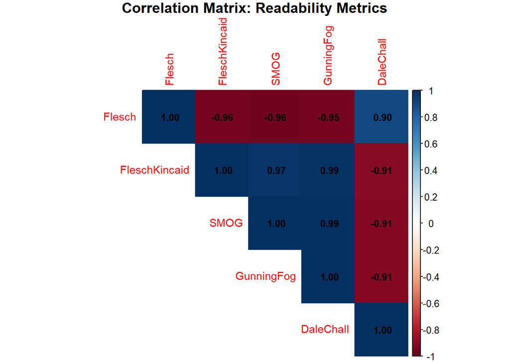

```r
# ===============================
# 3️⃣ Visualization
# ===============================
corrplot(
  cor_matrix,
  method = "color",
  type = "upper",
  addCoef.col = "black",
  tl.cex = 0.9,
  number.cex = 0.8,
  title = "Correlation Matrix: Readability Metrics",
  mar = c(0, 0, 1, 0)
)
```

### Visualization Readability Scores

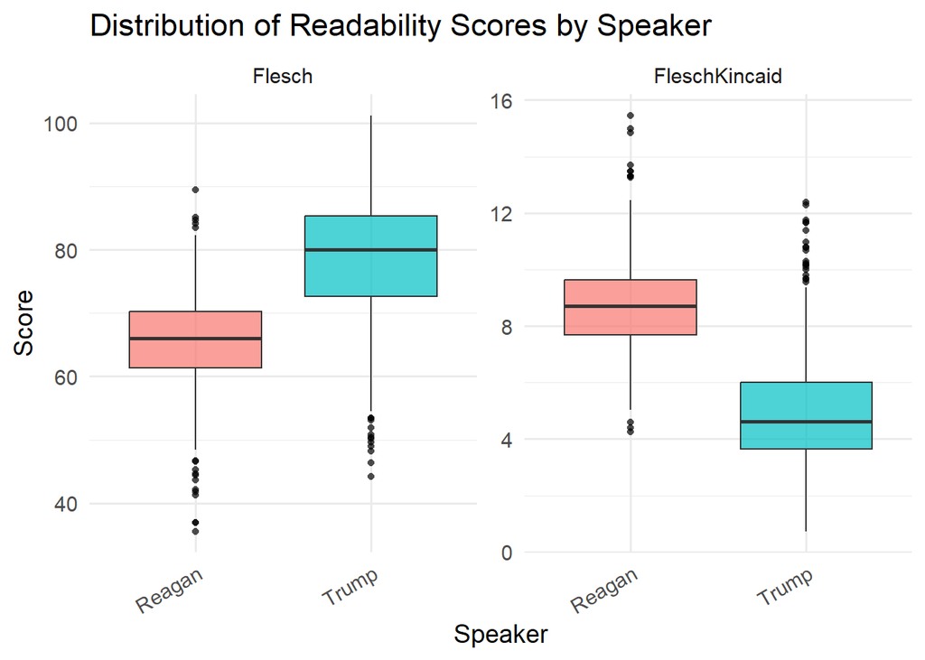

```r
library(dplyr)
library(tidyr)
library(ggplot2)

# -----------------------------
# 1. Prepare data for plotting
# -----------------------------
plot_df <- corpus_df %>%
  select(speaker, Flesch, FleschKincaid) %>%  # just select existing columns
  pivot_longer(
    cols = c(Flesch, FleschKincaid),
    names_to = "metric",
    values_to = "value"
  )

# -----------------------------
# 2. Plot boxplots
# -----------------------------
ggplot(plot_df, aes(x = speaker, y = value, fill = speaker)) +
  geom_boxplot(alpha = 0.7, outlier.color = "black", outlier.shape = 16) +
  facet_wrap(~ metric, ncol = 2, scales = "free_y") +
  labs(
    title = "Distribution of Readability Scores by Speaker",
    x = "Speaker",
    y = "Score"
  ) +
  theme_minimal(base_size = 14) +
  theme(
    legend.position = "none",
    axis.text.x = element_text(angle = 30, hjust = 1)
  )
```

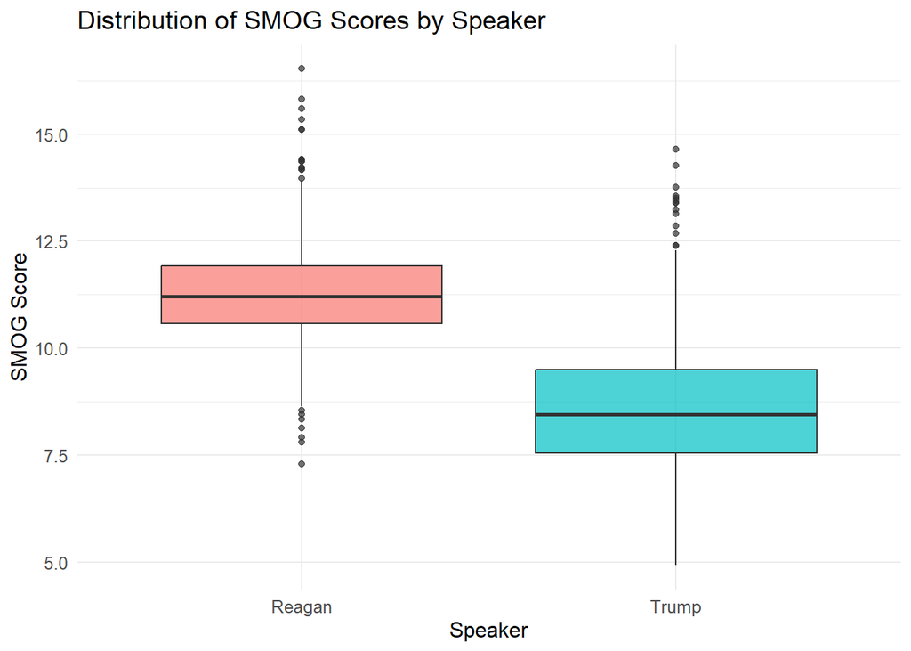

```r
ggplot(corpus_df, aes(x = speaker, y = SMOG, fill = speaker)) +
  geom_boxplot(alpha = 0.7) +
  labs(
    title = "Distribution of SMOG Scores by Speaker",
    x = "Speaker",
    y = "SMOG Score"
  ) +
  theme_minimal() +
  theme(
    text = element_text(size = 12),
    legend.position = "none"
  )
```

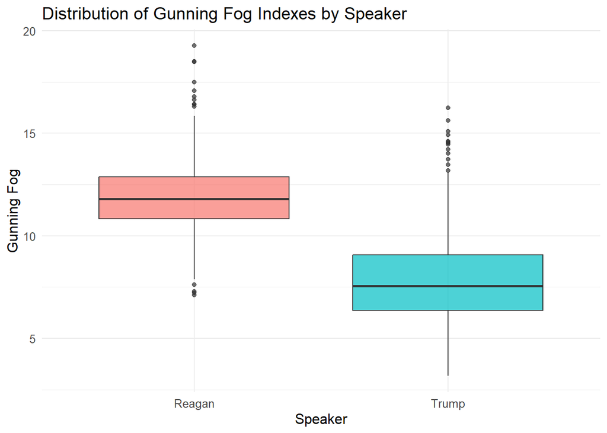

```r
ggplot(corpus_df, aes(x = speaker, y = GunningFog, fill = speaker)) +
  geom_boxplot(alpha = 0.7) +
  labs(
    title = "Distribution of Gunning Fog Indexes by Speaker",
    x = "Speaker",
    y = "Gunning Fog"
  ) +
  theme_minimal() +
  theme(
    text = element_text(size = 12),
    legend.position = "none"
  )
```

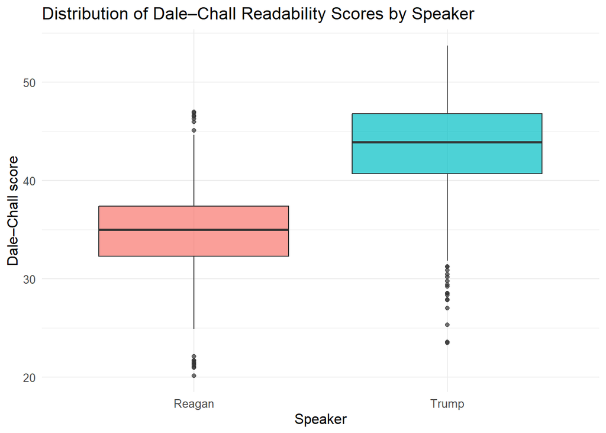

```r
library(ggplot2)

ggplot(corpus_df, aes(x = speaker, y = DaleChall, fill = speaker)) +
  geom_boxplot(alpha = 0.7) +
  labs(
    title = "Distribution of Dale–Chall Readability Scores by Speaker",
    x = "Speaker",
    y = "Dale–Chall score"
  ) +
  theme_minimal() +
  theme(
    text = element_text(size = 12),
    legend.position = "none"
  )
```

### Selecting less/most Readable Chunks

```r
library(dplyr)

# Define the chunks of interest
selected_chunks <- c("262-1", "072-1", "147-3", "011-1")

# Filter corpus_df for these chunks and select relevant columns
chunks_table <- corpus_df %>%
  filter(chunk_id %in% selected_chunks) %>%
  select(
    chunk_id, speaker, ntokens, nsentences,
    Flesch, FleschKincaid, DaleChall, SMOG, GunningFog, text
  )

# View the table
print(chunks_table)
```

```
## # A tibble: 4 × 10
##   chunk_id speaker ntokens nsentences Flesch FleschKincaid DaleChall  SMOG
##   <chr>    <chr>     <int>      <int>  <dbl>         <dbl>     <dbl> <dbl>
## 1 011-1    Reagan      877         30   36.9        15.5        21.2 16.5
## 2 072-1    Reagan      419         30   89.5         4.25       46.9  7.30
## 3 262-1    Trump       621         30   44.2        12.3        25.3 14.3
## 4 147-3    Trump       190         30  101.          0.734      46.7  5.46
## # ℹ 2 more variables: GunningFog <dbl>, text <chr>
```

```r
# Optionally, for a nicer table in RMarkdown or exporting to Word/Excel:
# library(knitr)
# kable(chunks_table, caption = "Readability Metrics for Selected Chunks")
```

### Visualizing word that are not in the Dalle-Chall word list 1995

word list obtained from: ReadabilityFormulas.com. (n.d.). The Dale-Chall 3,000 word list for readability formulas. ReadabilityFormulas.com. Retrieved February 26, 2026, from https://readabilityformulas.com/word-lists/the-dale-chall-word-list-for-readability-formulas/

```r
library(wordcloud)
# --- Prepare Dale-Chall list ---
dale_lines <- readLines("dale_chall_words.txt", encoding = "UTF-8")
dale_words <- tolower(unlist(strsplit(dale_lines, "\\s+")))
dale_words <- dale_words[dale_words != ""]

# --- Tokenize corpus without lemmatization ---
corpus_tokens <- balanced_chunks %>%
  select(speaker, text) %>%
  unnest_tokens(token, text) %>%
  # Remove punctuation, numbers, symbols, and common stopwords
  filter(
    !token %in% stop_words$word,
    !grepl("^[[:punct:][:digit:]]+$", token),
    !is.na(token),
    token != "'s"
  ) %>%
  mutate(token = tolower(token)) %>%
  mutate(non_dale = !(token %in% dale_words))

# --- Top non-Dale-Chall words per speaker ---
non_dale_tokens <- corpus_tokens %>%
  filter(non_dale) %>%
  count(speaker, token, sort = TRUE)

# --- Separate by speaker ---
non_dale_reagan <- non_dale_tokens %>% filter(speaker == "Reagan")
non_dale_trump <- non_dale_tokens %>% filter(speaker == "Trump")
```

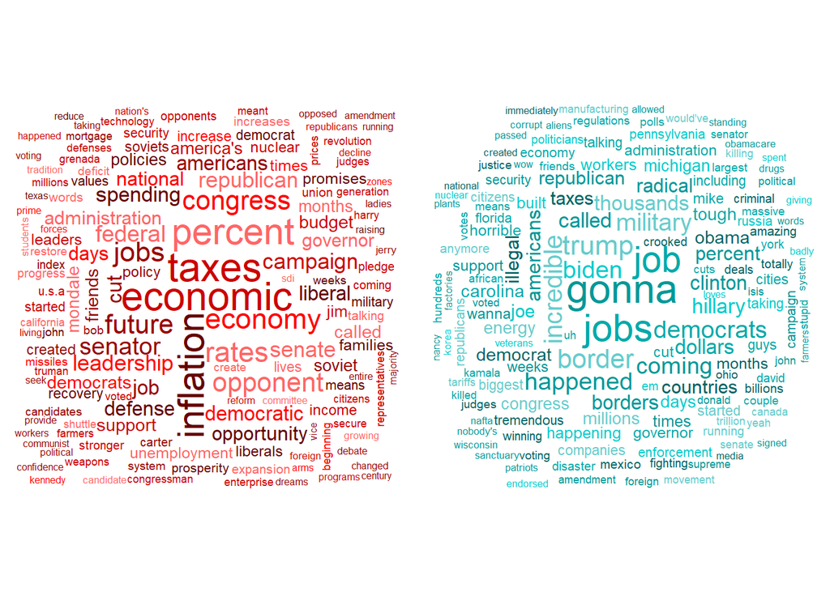

```r
library(wordcloud)

# --- Wordcloud function with custom colors ---
plot_wordcloud_colors <- function(df, colors) {
  set.seed(123)
  wordcloud(
    words = df$token,
    freq  = df$n,
    max.words = 150,
    scale = c(2, 0.3),                  # smaller words to fit more
    colors = sample(colors, length(df$token), replace = TRUE),
    random.order = FALSE
  )
}

# --- Define color palettes ---
reagan_colors <- c("#FF6666", "#FF0000", "#CC0000", "#990000", "#660000")
trump_colors  <- c("#66CCCC", "#00CCCC", "#00AAAA", "#009999", "#006666")

# --- Side-by-side plotting ---
par(mfrow = c(1,2), mar = c(0,0,0,0))  # 1 row, 2 columns, no margins

# Reagan wordcloud
plot_wordcloud_colors(non_dale_reagan, reagan_colors)
# Trump wordcloud
plot_wordcloud_colors(non_dale_trump, trump_colors)
```

```r
# Reset plotting layout
par(mfrow = c(1,1))
```

### Comparison: Word Familiarity vs Word Complexity

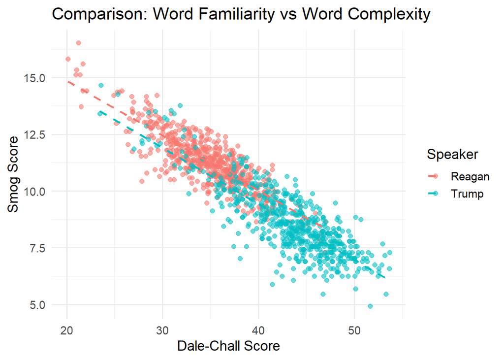

```r
# DaleChall vs SMOG

# Scatter plot: Dale-Chall vs Gunning Fog
ggplot(corpus_df, aes(x = DaleChall, y = SMOG, color = speaker)) +
  geom_point(alpha = 0.6, size = 2) +            # points for each chunk
  geom_smooth(method = "lm", se = FALSE, linetype = "dashed") + # optional trend line
  labs(
    title = "Comparison: Word Familiarity vs Word Complexity",
    x = "Dale-Chall Score",
    y = "Smog Score",
    color = "Speaker"
  ) +
  theme_minimal(base_size = 14)
```